# Exam_4

Elyza Lester

12/10/2021

Tasks:

1. ```
    Load and clean FacultySalaries_1995.csv file
   ```

   Re-create the graph shown in “fig1.png” Export it to your Exam_3 folder as LASTNAME_Fig_1.jpg (note, that’s a jpg, not a png) Please pay attention to what variables are on this graph. This task is really all about whether you can make a tidy dataset out of something a bit wonky. Refer back to the video where we cleaned “Bird_Measurements.csv”

```r
df <- read_csv("FacultySalaries_1995.csv")
```

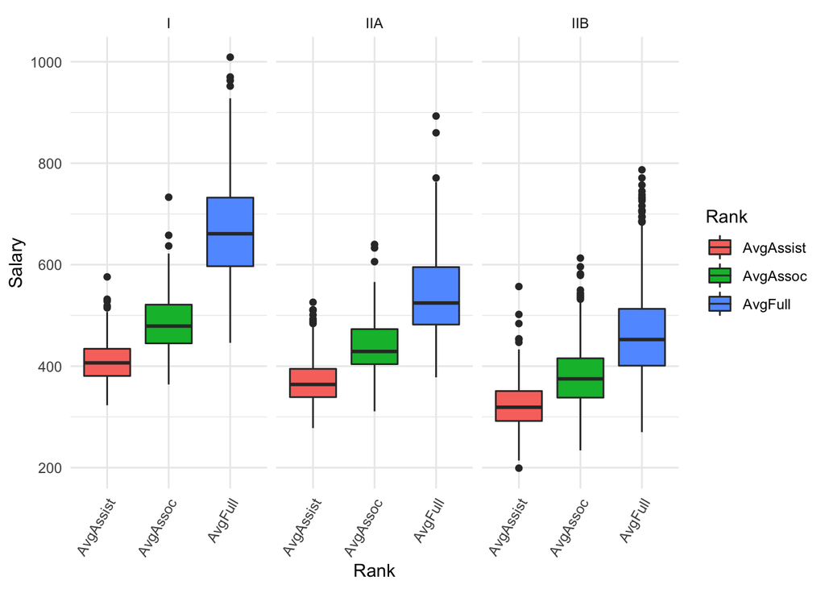

```r
clean_df <- df %>%
  select(ends_with("Salary"), "FedID", "Tier", "State") %>%
  pivot_longer(starts_with("Avg"),
               names_to ="Rank",
               values_to = "Salary",
               names_prefix = "avg") %>%
  mutate(Rank = str_remove_all(Rank, "ProfSalary")) %>%
  filter(Tier!= "VIIB")

ggplot(clean_df, aes(x= Rank, y= Salary, fill =Rank))+
  geom_boxplot() +
  facet_wrap (~Tier) +
  theme(axis.text.x = element_text(angle = 60, hjust = 1))
```

```r
ggsave("LESTER_Fig_1.jpg")
```

2. ```
   Export an ANOVA table to a file called "Salary_ANOVA_Summary.txt"
   The ANOVA model should test the influence of "State", "Tier", and "Rank" on "Salary" but should NOT include any interactions between those predictors.
   ```

```r
Mod <- clean_df %>%
  aov(Salary~ State + Tier + Rank, data = .)

capture_a <- summary(Mod)
capture.output(capture_a, file = "Salary_ANOVA_Summary.txt")
```

3. The rest of the test uses another data set. The “Juniper_Oils.csv” data. Get it loaded and take a look. It’s not exactly tidy either. Get used to that. It’s real data collected as part of a collaboration between Young Living Inc. and UVU Microbiology. A number of dead cedar trees were collected and the chemical composition of their essential oil content was measured. The hypothesis was that certain chemicals would degrade over time since they died in fires. So there are a bunch of columns for chemical compounds, and a column for “YearsSinceBurn.” The values under each chemical are Mass-Spec concentrations. Those are the ones the columns we care about for the purposes of this exam. Guess what, I’m giving you a nicely formatted list of the chemical compounds: c(“alpha-pinene”,“para-cymene”,“alpha-terpineol”,“cedr-9-ene”,“alpha-cedrene”,“beta-cedrene”,“cis-thujopsene”,“alpha-himachalene”,“beta-chamigrene”,“cuparene”,“compound 1”,“alpha-chamigrene”,“widdrol”,“cedrol”,“beta-acorenol”,“alpha-acorenol”,“gamma-eudesmol”,“beta-eudesmol”,“alpha-eudesmol”,“cedr-8-en-13-ol”,“cedr-8-en-15-ol”,“compound 2”,“thujopsenal”)

```r
df2 <- read_csv("Juniper_Oils.csv")
Chems <- c("alpha-pinene","para-cymene","alpha-terpineol","cedr-9-ene","alpha-cedrene","beta-cedrene","cis-thujopsene","alpha-himachalene","beta-chamigrene","cuparene","compound 1","alpha-chamigrene","widdrol","cedrol","beta-acorenol","alpha-acorenol","gamma-eudesmol","beta-eudesmol","alpha-eudesmol","cedr-8-en-13-ol","cedr-8-en-15-ol","compound 2","thujopsenal")

clean2 <- df2 %>%
  pivot_longer(Chems,
               names_to = "Compound",
               values_to = "Concentration")
```

```
## Note: Using an external vector in selections is ambiguous.
## ℹ Use `all_of(Chems)` instead of `Chems` to silence this message.
## ℹ See <https://tidyselect.r-lib.org/reference/faq-external-vector.html>.
```

4. ```
   Make me a graph of the following:
   x = YearsSinceBurn
   y = Concentration
   facet = ChemicalID (use free y-axis scales)
   See Fig2.png for an idea of what I'm looking for
   ```

[figure not shown]

```r
clean2 %>%
  ggplot(aes(x=YearsSinceBurn, y= Concentration))+
  geom_smooth()+
  facet_wrap(~Compound, scales = "free_y")
```

```r
mod2 <-glm(data = clean2,
           formula = Concentration ~ Compound * YearsSinceBurn)

tidy(mod2) %>%
  filter(p.value < 0.05) %>%
  mutate(term= str_remove_all(term, "Compound"))
```

```
## # A tibble: 6 × 5
##   term                          estimate std.error statistic  p.value
##   <chr>                            <dbl>     <dbl>     <dbl>    <dbl>
## 1 alpha-cedrene                    7.88      1.93       4.08 4.97e- 5
## 2 cedr-8-en-13-ol                  7.62      1.93       3.95 8.72e- 5
## 3 cedrol                          22.5       1.93      11.7  5.12e-29
## 4 cis-thujopsene                  17.3       1.93       8.95 2.93e-18
## 5 widdrol                          5.82      1.93       3.01 2.69e- 3
## 6 cis-thujopsene:YearsSinceBurn    0.332     0.141      2.35 1.90e- 2
```

6. ```
   Commit and push all your code and files to GitHub. I'll pull your repository and grade what I find.
   ```

7. For 10 bonus points, put all this code and output into a fancy knitted html file instead of just an R script.